# Revisitando a análise das Cotas Parlamentares

Bruno Dias - contato@diasbruno.com

April 12, 2016

## Problema

Nesta atividade o propósito é melhorar uma visualização feita em algum problema resolvido de atividades anteriores. Para solução do problema, será necessário:

- Uma visualização que tenha ao menos **três** variáveis;
- Siga boas práticas de visualização discutidas;
- Tenha valores plenamente legíveis;
- Esteja dentro de um documento PDF que tem formato do texto em **duas** colunas;
- A figura deve ter a largura de uma coluna e deve ser facilmente legível com zoom de 100%;
- Deve mostrar a imagem anterior e a nova imagem, um texto que explica qual a tarefa que a visualização pretende apoiar e uma breve explicação do que foi modificado.

## Análise inicial

Na análise inicial foi feito uma visualização que mostra os deputados do estado da Paraíba que ultrapassaram o limite da cota parlamentar definida para o estado. Podemos ver a visualização na figura abaixo.

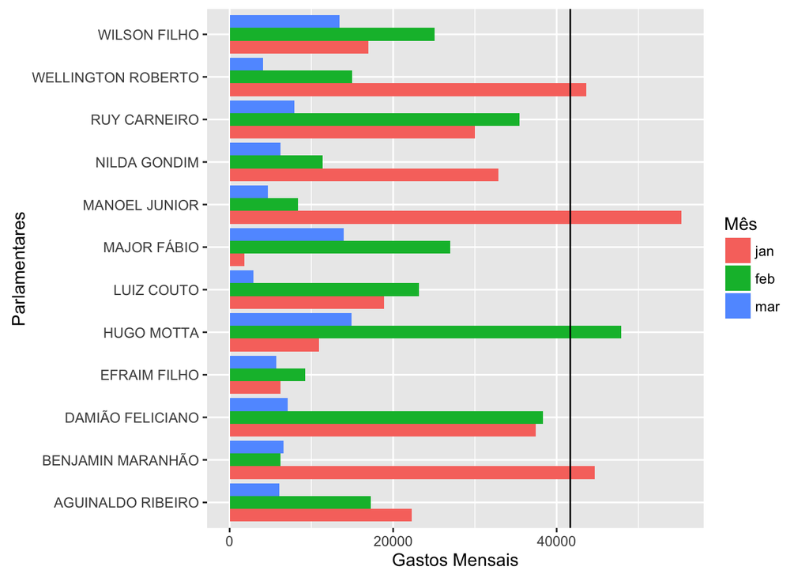

```r
ggplot(comb.m, aes(x=nome, y=value)) +
  xlab("Parlamentares") +
  ylab("Gastos Mensais") +
  geom_bar(aes(fill=Mês),
          position = "dodge",
          stat="identity") +
  coord_flip() +
  geom_hline(yintercept = limite)
```

## Visualização melhorada

Na figura abaixo, temos a visualização da mesma análise com alguns ajustes importantes. A ideia foi melhorar a organização dos dados dessa visualização, ordenando os gastos totais de cada deputado no período. Assim, podemos perceber algo interessante que não tinha sido possível no análise anterior, o deputado **Damião Feliciano** teve o maior gasto no período, mesmo sem estourar sua cota parlamentar.

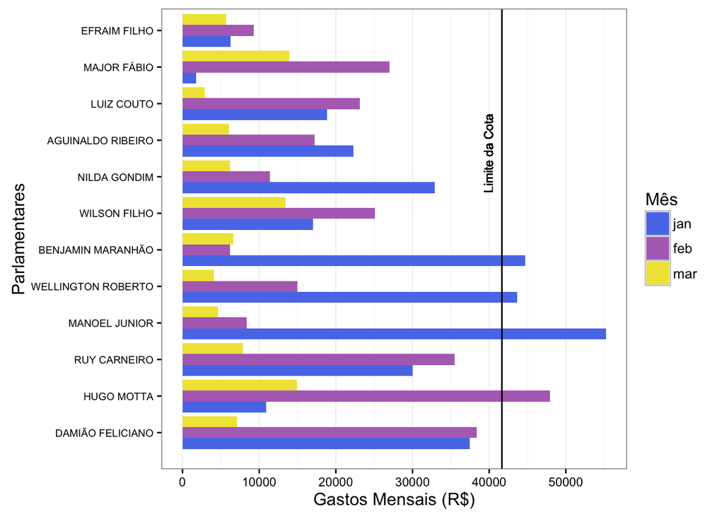

```r
ggplot(comb.m,
       aes(x=reorder(nome, -value),
          y=value, fill=Mês)) +
  geom_bar(position = "dodge",
          stat="identity") +
  geom_hline(yintercept = limite) +
  geom_text(
    aes(0, limite, label = "Limite da Cota"),
            vjust = -1, hjust = -3.5,
            angle = 90, size = 3) +
  xlab("Parlamentares") +
  scale_y_continuous(
    name ="Gastos Mensais (R$)",
    breaks=seq(0, 60000, 10000))+
  scale_fill_manual(
    values = alpha(
      c("#5a7cea","#b370bf", "#F0E442"))) +
  coord_flip() +
  theme_bw() +
  theme(axis.text.x =
          element_text(size = rel(0.9)),
        axis.text.y =
          element_text(size = rel(0.75)),
        panel.grid.major.y = element_blank())
```

Por fim, outros pontos foram melhorados, tais como:

- Adição de uma legenda na linha vertical que define o limite de cota mensal
- Diminuição do tamanho da fonte dos nomes dos deputados, tendo a preocupação de deixar um tamanho bom o suficiente para leitura
- Adição da unidade monetária(R$) para facilitar o entendimento do eixo X
- Aumento da escala de valores no eixo X para facilitar a leitura do gráfico
- Mudança nas cores das barras com o objetivo de deixar o gráfico mais acessível para daltônicos.
- Mudança no grid do gráfico, mantendo só as linhas verticais, já que as horizontais não influenciavam na leitura do gráfico.